# 2.8 Global temperature

### Unit 2: Climate

#### Lesson 8: Global Temperature

#### Skills: if statements, for loops, user-defined functions

### Examining global temperature trends

- Data from: http://climate.nasa.gov/vital-signs/global-temperature
- Raw data: https://data.giss.nasa.gov/gistemp/graphs/graph_data/Global_Mean_Estimates_based_on_Land_and_Ocean_Data/graph.txt

NASA’s Goddard Institute of Space Studies (outside Washington D.C.) has created an annual global land-ocean temperature index. Many of the last years have set new records on global temperature. In this section we will download, explore and analyze global mean temperature data.

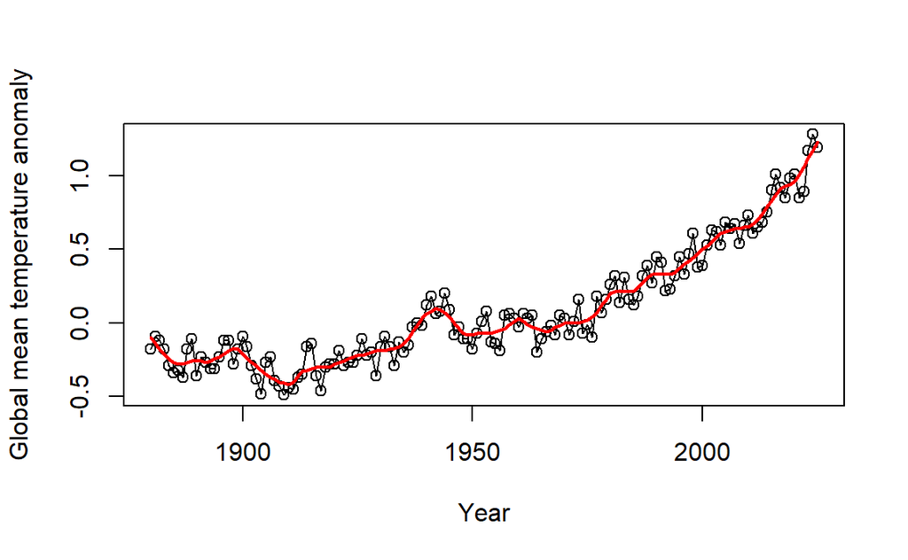

```
## integer(0)
```

```r
# temp_anomaly = read.table("data/global_temp_data_1880-2022.txt", skip=5, sep="", header = FALSE, col.names = c("Year", "No_Smoothing", "Lowess_5"))
url = 'https://data.giss.nasa.gov/gistemp/graphs/graph_data/Global_Mean_Estimates_based_on_Land_and_Ocean_Data/graph.txt'
temp_anomaly = read.delim(url, skip=5, sep="", header=FALSE, col.names = c("Year", "No_Smoothing", "Lowess_5"))
class(temp_anomaly)
## [1] "data.frame"
head(temp_anomaly)
##   Year No_Smoothing Lowess_5
## 1 1880        -0.18    -0.10
## 2 1881        -0.09    -0.14
## 3 1882        -0.12    -0.18
## 4 1883        -0.18    -0.21
## 5 1884        -0.29    -0.25
## 6 1885        -0.34    -0.27
dim(temp_anomaly)
## [1] 146   3
summary(temp_anomaly)
##       Year       No_Smoothing         Lowess_5
##  Min.   :1880   Min.   :-0.49000   Min.   :-0.42000
##  1st Qu.:1916   1st Qu.:-0.20000   1st Qu.:-0.22000
##  Median :1952   Median :-0.03000   Median :-0.03500
##  Mean   :1952   Mean   : 0.08158   Mean   : 0.08226
##  3rd Qu.:1989   3rd Qu.: 0.31750   3rd Qu.: 0.32500
##  Max.   :2025   Max.   : 1.28000   Max.   : 1.23000

plot(No_Smoothing ~ Year, data=temp_anomaly, ylab="Global mean temperature anomaly") + # type="b") #as points
  lines(No_Smoothing ~ Year, data=temp_anomaly) + #as a line
  lines(Lowess_5 ~ Year, data=temp_anomaly, col="red", lwd=2)
```

### Evaluating the evidence for a “Pause” in warming?

The [2013 IPCC Report](https://www.ipcc.ch/report/ar5/syr/) included a tentative observation of a “much smaller increasing trend” in global mean temperatures since 1998 than was observed previously. This led to much discussion in the media about the existence of a “Pause” or “Hiatus” in global warming rates, as well as much research looking into where the extra heat could have gone. (Examples discussing this question include articles in [The Guardian](http://www.theguardian.com/environment/2015/jun/04/global-warming-hasnt-paused-study-finds), [BBC News](http://www.bbc.com/news/science-environment-28870988), and [Wikipedia](https://en.wikipedia.org/wiki/Global_warming_hiatus)).

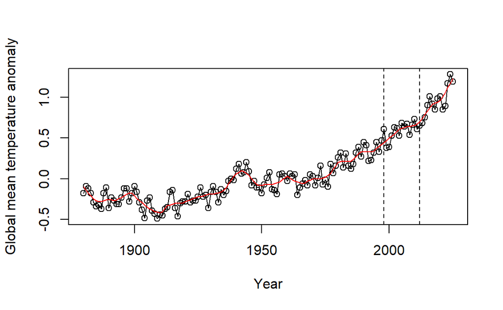

```
## integer(0)
```

```r
plot(No_Smoothing ~ Year, data=temp_anomaly, ylab="Global mean temperature anomaly") +
  lines(No_Smoothing ~ Year, data=temp_anomaly) +
  lines(Lowess_5 ~ Year, data=temp_anomaly, col="red") +
  abline(v=1998, lty="dashed") +
  abline(v=2012, lty="dashed") # 2012 would be the "current state" when writing the 2013 IPCC report
```

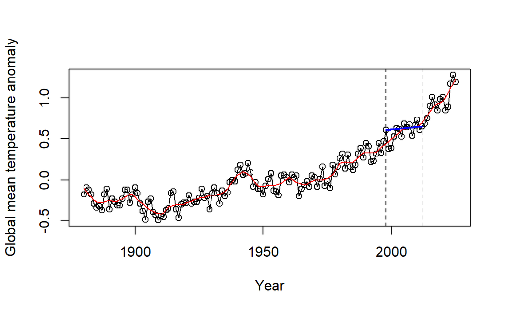

```
## integer(0)
```

```r
temp_1998 = temp_anomaly$No_Smoothing[temp_anomaly$Year==1998]
temp_2012 = temp_anomaly$No_Smoothing[temp_anomaly$Year==2012]

plot(No_Smoothing ~ Year, data=temp_anomaly, ylab="Global mean temperature anomaly") +
  lines(No_Smoothing ~ Year, data=temp_anomaly) +
  lines(Lowess_5 ~ Year, data=temp_anomaly, col="red") +
  abline(v=1998, lty="dashed") +
  abline(v=2012, lty="dashed") +
  lines(c(temp_1998, temp_2012)~c(1998, 2012), col="blue", lwd=2) # used the lwd parameter to thicken the line. See ?par
```

Now that we can see the 1998-2012 trend that was discussed in the 2013 IPCC report, it does seem like the rate of warming has slowed way down. However, now that we have the luxury of another decade of data, those dates seem completely cherry-picked and there is no observable slow-down to speak of.

### Calculating rolling averages

In the last lesson we calculated annual averages and 5 year averages to get a smoother look at our data and be less susceptible to random perturbations. In that lesson, we defined the 5 year average as the average of the data from a given year along with the 2 years before and 2 years after (i.e. the 5-year rolling average of 2005 temperature = the temperature mean from 2003-2007).

Sometimes scientists calculate moving averages where they simply just look at the period prior to a given year. For example, we could define a 5 year average as the average over a given year and the 4 years prior (i.e. the 5-year rolling average of 2005 temperature = the average temperature from 2001-2005). Either definition is acceptable as long as you are explicit with which definition you are using. The advantage of calculating moving averages for an endpoint (instead of a midpoint) is that they are slightly simpler to calculate and you can provide averages up to the most current date. For this lesson, we’ll calculate moving averages using the simpler end-point definition.

Let’s create a user defined function that will calculate the moving average for any vector of numbers, and the user can choose what the size of the moving window will be (i.e. whether it will be a 1-year average, 5-year average, 10-year average, etc.).

- Define a 5 year average as the average over a given year and the 4 years prior.
- Construct 5 year averages from the annual data. Construct 10 & 20-year averages.
- Plot the different averages and describe what differences you see and why.

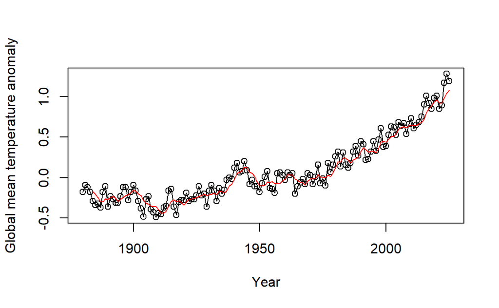

```
## integer(0)
```

```r
# User defined function to calculate a rolling average of a vector for a user-specified moving window
# The rolling averages are calculated with the reference year as the ENDPOINT for the moving window
# Averages are not calculated for data points prior to the first time point when the full moving window can be included in the average
# Default size of the moving window is set at 5 units of time
# Note that this function is designed to calculate moving averages in data that are collected regularly with even temporal spacing

calc_rolling_avg = function(data, moving_window=5){
  result = rep(NA, length(data)) # initialize results vector
  for (i in seq(from=moving_window, to=length(data))){
    result[i] = mean(data[seq(from=(i-moving_window+1), to=i)])
  }
  return(result)
}

temp_anomaly$avg_5_yr = calc_rolling_avg(temp_anomaly$No_Smoothing)

head(temp_anomaly)
##   Year No_Smoothing Lowess_5 avg_5_yr
## 1 1880        -0.18    -0.10       NA
## 2 1881        -0.09    -0.14       NA
## 3 1882        -0.12    -0.18       NA
## 4 1883        -0.18    -0.21       NA
## 5 1884        -0.29    -0.25   -0.172
## 6 1885        -0.34    -0.27   -0.204
tail(temp_anomaly)
##     Year No_Smoothing Lowess_5 avg_5_yr
## 141 2020         1.01     0.96    0.954
## 142 2021         0.85     1.01    0.922
## 143 2022         0.89     1.06    0.916
## 144 2023         1.17     1.12    0.980
## 145 2024         1.28     1.17    1.040
## 146 2025         1.19     1.23    1.076

plot(No_Smoothing ~ Year, data=temp_anomaly, ylab="Global mean temperature anomaly") +
  lines(No_Smoothing ~ Year, data=temp_anomaly) +
  lines(avg_5_yr ~ Year, data=temp_anomaly, col="red")
```

Let’s save this plot as a PDF file so we can put it in a publication, powerpoint, or just show it to Grandma at Thanksgiving:

```r
pdf('figures/global_mean_temp.pdf', width=7, height=5)
plot(No_Smoothing ~ Year, data=temp_anomaly, ylab="Global mean temperature anomaly") +
  lines(No_Smoothing ~ Year, data=temp_anomaly) +
  lines(avg_5_yr ~ Year, data=temp_anomaly, col="red")
## integer(0)
dev.off()
## png
##   2
```

### Exercise 8.1

Calculate the 10-year and 20-year rolling averages of the temperature anomaly data using our new user defined function `calc_rolling_average`. Plot the 5, 10 and 20 year rolling averages onto the same figure. How would you change the design of the function if you wanted it to calculate the moving average where the reference year was at the midpoint of the moving window, rather than the endpoint of the moving window?

Do you see the advantage of this? Once your rolling average user defined function has been written, you can repeat this type of calculation on any of your diverse datasets with a very easy-to-use line of code.

To use this function in future code, you can copy and paste the function at the top of your new R scripts. Or you could save it in an `.R` script on its own and import that script at the top of any new R scripts that you build using the `source()` function. If you were really ambitious, you could put your function into a time series analysis package and make it available on CRAN.